# Problem Set 1

Statistics and Econometrics

Konstantinos Paganopoulos

## Question 1

> The data set ceosal2.RData contains information on chief executive officers for U.S. corporations. Two variables of interest are the annual compensation ($salary$) and the prior number of years as company CEO ($ceoten$).
> 1. Find the average salary and the average tenure in the sample.

```r
load("ceosal2.RData")
ls() # show data sets and functions defined
```

```
## [1] "data" "desc" "self"
```

```r
desc
```

| variable | label |
| --- | --- |
| salary | 1990 compensation, $1000s |
| age | in years |
| college | =1 if attended college |
| grad | =1 if attended graduate school |
| comten | years with company |
| ceoten | years as ceo with company |
| sales | 1990 firm sales, millions |
| profits | 1990 profits, millions |
| mktval | market value, end 1990, mills. |
| lsalary | log(salary) |

[output cut: 5 more lines]

We rename the data frame with a more informative name

```r
ceosal.data <- data
```

As the first step for any data analysis, we will need to get familiar with the data set by investigating summary statistics, univariate plot, and pairwise plot.

```r
summary(ceosal.data[, 1:15])
```

```
##      salary            age           college            grad
##  Min.   : 100.0   Min.   :33.00   Min.   :0.0000   Min.   :0.0000
##  1st Qu.: 471.0   1st Qu.:52.00   1st Qu.:1.0000   1st Qu.:0.0000
##  Median : 707.0   Median :57.00   Median :1.0000   Median :1.0000
##  Mean   : 865.9   Mean   :56.43   Mean   :0.9718   Mean   :0.5311
##  3rd Qu.:1119.0   3rd Qu.:62.00   3rd Qu.:1.0000   3rd Qu.:1.0000
##  Max.   :5299.0   Max.   :86.00   Max.   :1.0000   Max.   :1.0000
##      comten         ceoten           sales          profits
##  Min.   : 2.0   Min.   : 0.000   Min.   :   29   Min.   :-463.0
##  1st Qu.:12.0   1st Qu.: 3.000   1st Qu.:  561   1st Qu.:  34.0
##  Median :23.0   Median : 6.000   Median : 1400   Median :  63.0
##  Mean   :22.5   Mean   : 7.955   Mean   : 3529   Mean   : 207.8
##  3rd Qu.:33.0   3rd Qu.:11.000   3rd Qu.: 3500   3rd Qu.: 208.0
##  Max.   :58.0   Max.   :37.000   Max.   :51300   Max.   :2700.0
##      mktval         lsalary          lsales          lmktval
##  Min.   :  387   Min.   :4.605   Min.   : 3.367   Min.   : 5.958
##  1st Qu.:  644   1st Qu.:6.155   1st Qu.: 6.330   1st Qu.: 6.468
##  Median : 1200   Median :6.561   Median : 7.244   Median : 7.090
##  Mean   : 3600   Mean   :6.583   Mean   : 7.231   Mean   : 7.399
##  3rd Qu.: 3500   3rd Qu.:7.020   3rd Qu.: 8.161   3rd Qu.: 8.161
##  Max.   :45400   Max.   :8.575   Max.   :10.845   Max.   :10.723
##     comtensq         ceotensq         profmarg
##  Min.   :   4.0   Min.   :   0.0   Min.   :-203.077
##  1st Qu.: 144.0   1st Qu.:   9.0   1st Qu.:   4.231
##  Median : 529.0   Median :  36.0   Median :   6.834
##  Mean   : 656.7   Mean   : 114.1   Mean   :   6.420
##  3rd Qu.:1089.0   3rd Qu.: 121.0   3rd Qu.:  10.947
##  Max.   :3364.0   Max.   :1369.0   Max.   :  47.458
```

We focus on the two variables of interest, $salary$ and $ceoten$.

```r
summary(ceosal.data[, 1:1])
```

```
##    Min. 1st Qu.  Median    Mean 3rd Qu.    Max.
##   100.0   471.0   707.0   865.9  1119.0  5299.0
```

Hence the average $salary$ is 865.9

```r
summary(ceosal.data[, 6:6])
```

```
##    Min. 1st Qu.  Median    Mean 3rd Qu.    Max.
##   0.000   3.000   6.000   7.955  11.000  37.000
```

Hence the average $ceoten$ (tenure) 7.955

> 2. How many CEOs are in their first year as CEO (that is, $ceoten=0$)? What is the longest tenure as a CEO?

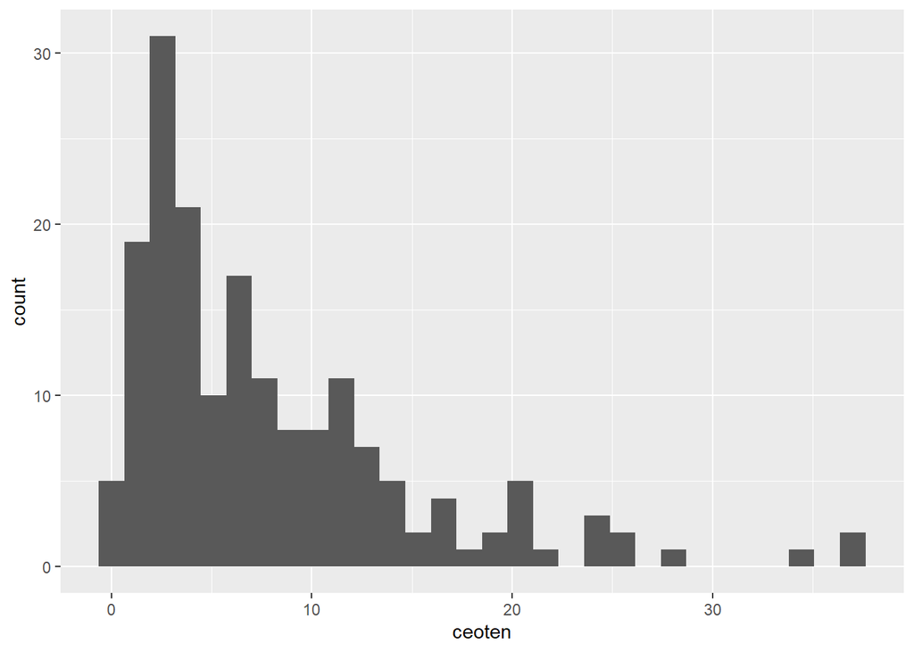

```r
ggplot(data = ceosal.data, aes(x = ceoten)) + geom_histogram()
```

From the histogram we see that 5 CEOs are in their first year as CEO and the longest tenure is 37 years.

> 3. What is the average salary for CEOs with tenure longer than or equal to the average tenure? What is the average salary for CEOs with tenure shorter than the average tenure?

```r
library(dplyr)
ceosal2 <- ceosal.data %>%
            select(salary, ceoten) %>%
            filter(ceoten >= mean(ceosal.data$ceoten))
sal_avg.above <- mean(ceosal2$salary)

cat("Average salary of CEOs with tenure longer than or equal to average is $", round(sal_avg.above *1000))
```

```
## Average salary of CEOs with tenure longer than or equal to average is $ 1003500
```

```r
ceosal2 <- ceosal.data %>%
            select(salary, ceoten) %>%
            filter(ceoten < mean(ceosal.data$ceoten))
sal_avg.below <- mean(ceosal2$salary)

cat("Average salary of CEOs with tenure shorter than average is $", round(sal_avg.below *1000))
```

```
## Average salary of CEOs with tenure shorter than average is $ 766981
```

> 4. Create a graph to examine the relationship between $salary$ and $ceoten$ for all CEOs. Comment.

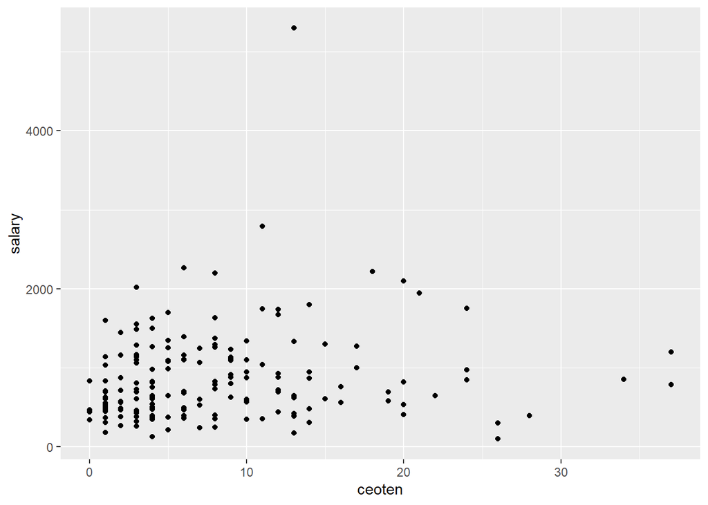

```r
ggplot(data = ceosal.data, aes(x = ceoten, y = salary)) + geom_point()
```

We investigate the scatterplot of $salary$ vs $ceoten$. It shows that for approximately the first 10 years $salary$ increases as $ceoten$ increases. Moreover, we have few observations with more than 20 years of experience as CEOs, which will impact the accuracy of prediction for higher levels of ceo tenure; It is also worth mentioning that the variation in $salary$ does not generally increases in $ceoten$ so we don’t have heteroskedasticity. The salary appears to be uniformly distributed across the tenure of the CEOs, i.e. the length of the tenure of the CEOs does not significantly affect the salary of the CEOs. There are also a number of CEOs who have 2-year tenure earning as much salary as those who have 15-year tenure. Lastly, it can be seen that the salary range largely falls between 0 to 2,000,000 for the sample. There is a cluster of data with CEO’s tenure between 0 to 10 years.

> 5. Estimate the simple regression model
>    $$\log(salary)=\beta_0+\beta_1 ceoten+u,$$
>    and report your results. What is the (approximate) predicted percentage increase in salary given one more year as a CEO?

```r
log.m1 <- lm(lsalary ~ ceoten, data = ceosal.data)
summary(log.m1)
```

```
##
## Call:
## lm(formula = lsalary ~ ceoten, data = ceosal.data)
##
## Residuals:
##      Min       1Q   Median       3Q      Max
## -2.15314 -0.38319 -0.02251  0.44439  1.94337
##
## Coefficients:
##             Estimate Std. Error t value Pr(>|t|)
## (Intercept) 6.505498   0.067991  95.682   <2e-16 ***
## ceoten      0.009724   0.006364   1.528    0.128
## ---
## Signif. codes:  0 '***' 0.001 '**' 0.01 '*' 0.05 '.' 0.1 ' ' 1
##
## Residual standard error: 0.6038 on 175 degrees of freedom
## Multiple R-squared:  0.01316,    Adjusted R-squared:  0.007523
## F-statistic: 2.334 on 1 and 175 DF,  p-value: 0.1284
```

```r
library(stargazer)
stargazer(log.m1, type = "html")
```

|  | *Dependent variable:* |
| --- | --- |
|  | lsalary |
| ceoten | 0.010 |
|  | (0.006) |
| Constant | 6.505*** |
|  | (0.068) |
| Observations | 177 |
| R<sup>2</sup> | 0.013 |
| Adjusted R<sup>2</sup> | 0.008 |
| Residual Std. Error | 0.604 (df = 175) |
| F Statistic | 2.334 (df = 1; 175) |
| *Note:* | p<0.1; p<0.05; p<0.01 |

From the above results we can see that the approcimate predicted precentage increase in salary given one more year as CEO is 0.009724 hence 0.97%

## Question 2

> The data set bwght.RData contains data on births to women in the United States. Two variables of interest are the infant birth weight in ounces ($bwght$), and the average number of cigarettes the mother smoked per day during pregnancy ($cigs$).
> 1. Estimate the simple regression model
>    $$bwght=\beta_0+\beta_1 cigs+u,$$
>    and report your results.

```r
load("bwght.RData") #load data set
```

We rename the data frame with a more informative name

```r
bwght.data <- data
```

We estimate the simple regression model
$$bwght=\beta_0+\beta_1 cigs+u,$$
and report the results

```r
linear.m1 <- lm(bwght ~ cigs, data = bwght.data)
summary(linear.m1)
```

```
##
## Call:
## lm(formula = bwght ~ cigs, data = bwght.data)
##
## Residuals:
##     Min      1Q  Median      3Q     Max
## -96.772 -11.772   0.297  13.228 151.228
##
## Coefficients:
##              Estimate Std. Error t value Pr(>|t|)
## (Intercept) 119.77190    0.57234 209.267  < 2e-16 ***
## cigs         -0.51377    0.09049  -5.678 1.66e-08 ***
## ---
## Signif. codes:  0 '***' 0.001 '**' 0.01 '*' 0.05 '.' 0.1 ' ' 1
##
## Residual standard error: 20.13 on 1386 degrees of freedom
## Multiple R-squared:  0.02273,    Adjusted R-squared:  0.02202
## F-statistic: 32.24 on 1 and 1386 DF,  p-value: 1.662e-08
```

```r
library(stargazer)
linear.m1 <- lm(bwght ~ cigs, data = bwght.data)
stargazer(linear.m1, type = 'html')
```

|  | *Dependent variable:* |
| --- | --- |
|  | bwght |
| cigs | -0.514*** |
|  | (0.090) |
| Constant | 119.772*** |
|  | (0.572) |
| Observations | 1,388 |
| R<sup>2</sup> | 0.023 |
| Adjusted R<sup>2</sup> | 0.022 |
| Residual Std. Error | 20.129 (df = 1386) |
| F Statistic | 32.235*** (df = 1; 1386) |
| *Note:* | p<0.1; p<0.05; p<0.01 |

According to the model:
$$bwght=119.77-0.5138 cigs$$
$$where$$
$$n = 1388, R^2 = 0.0227$$

Therefore with one more cigarette smoked per day during pregnancy, the birthweight is expected to decrease by around 0.5138 ounces.

> 2. What is the predicted birth weight when $cigs = 0$? What about when $cigs = 20$ (one pack per day)? Comment on the difference.

```r
predict(linear.m1, data.frame(cigs = c(0,20)))
```

```
##        1        2
## 119.7719 109.4965
```

The predicted birth weight when $cigs = 0$ is 119.77, whereas when $cigs = 20$ is 109.50, which is about an 8.6% drop.

The results are unsurprising, since for no cigaretters per day the infant birth weight in ounces is approximately 119.77 whereas for 20 ciagarettes per day (one pack per day) is significantly lower approximately at 109.50

Obviously, mothers who smoke cigarettes during pregnancy have, on average, lower birthweight children.

> 3. Does this simple regression necessarily capture a causal relationship between the child’s birth weight and the mother’s smoking habits? Explain.

Not necessarily. In this case, smoking precedes the birth of the child and therefore the incidence of smoking can be considered to be causal. However, there are probably many other factors that affect the birthweight of child such as income of the mother, overall health and nutrition of the mother (caffeine consumption), and environmental conditions (smog, pollution).

> 4. To predict a birth weight of $125$ ounces, what would $cigs$ have to be? Comment.

We saw in Question 2 part 2 that the predicted birth weight when $cigs = 0$ is 119.77

In other words, that birth weight is our best solution, since it is achieved with the consumption of 0 cigarettes by the mother.

As a result a birth weight of 125 ounces is clearly impossible. After all, the above regression equation implies that the “best” average birthrate for non-smokers is 119.77 ounces.

> 5. The proportion of women in the sample who do not smoke while pregnant is about $85\%$. Does this reconcile your finding from part 4?

We know that it would be better, in terms of sample design, to have more smokers in the sample because this would add to the variation in the independent variable (cigs) and we might get a more accurate estimate of the intercept which gives us the average birthweight of children of non-smoking mothers. It is possible that the intercept estimate might take on a more accurate estimate in this case and indicate the greater likelihood of having larger babies.

In other words, 85% of women did not smoke while pregnant. Because we are using only cigs to explain birth weight, we have only one predicted birth weight at cigs = 0. The predicted birth weight is necessarily roughly in the middle of the observed birth weights at cigs = 0, and so we will under predict high birth rates such as that of 125 ounces in part 4.